# Montreal’s Airbnb Listings in October 2015

Jake Russ

March 12, 2016

Flatbook’s recent study found that [bad spellers get fewer bookings](http://blog.flatbook.co/2016/03/bad-spellers-get-fewer-airbnb-bookings/) in Manhattan. I decided to return the favor to Flatbook HQ by investigating what drives Airbnb rental prices in Montreal. Fortunately, [Inside Airbnb](http://insideairbnb.com/about.html) hosts open sourced Airbnb listing data. The 8979 listing sample for this quick study comes from October 2015.

The first step in any analysis is to explore the raw data and clean it up as neccesary. After briefly exploring the data, I made two filtering decisions. First, I removed listings with prices above $1,000. That figure is arbitrary but it removes some listings that dramatically alter group averages. Second, because property type and neighbourhood are factors that will end up in the pricing model, I set a minimum threshold of 20 obervations for these group variables. This removed less frequently used descriptions such as, “Camper/RV” or “villa” and left us with the expected standards, “Apartment”, “House”, etc.

My “cleaned” data set includes 8831 listings, which means I trimmed about 1.65 percent of the original observations.

### Sanity check: What is the median daily price by Montreal neighbourhood?

I think vizualiations are the natural next step in an analysis and median price by neighbourhood is a sensible test to sanity check the data. Given my group level restrictions, the data contains 18 neighbourhoods for Montreal.

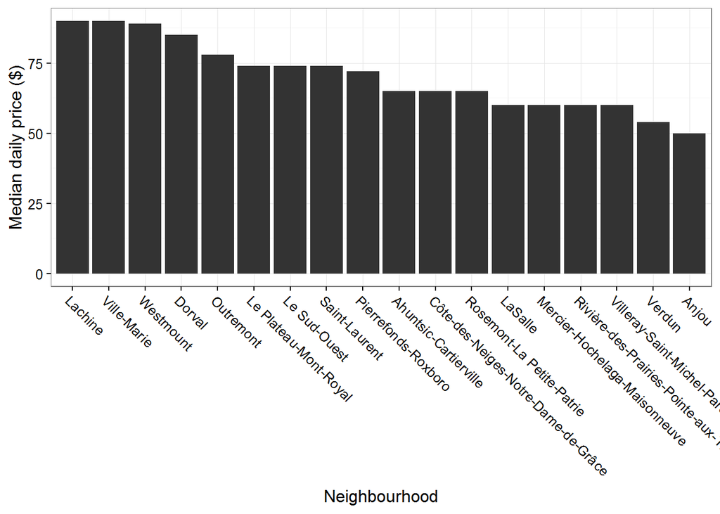

My knowledge of Montreal is admittedly limited but this plot appears to give the “expected” result because high-income areas like Ville-Marie (Downtown Montreal) and Westmount are at the top of the scale and a low-income area like Verdun is near the bottom.

### Linear regression results

The regression model I used includes the six variables I think should explain most of the variation in price, number of bedrooms, number of bathrooms, room type, property type, neighbourhood location, and Airbnb’s superhost designation.

To ease the reading of the results I do not report the individual neighbourhood factors.

[output not shown]

#### Interpret results

For the average one bedroom, one bathroom apartment the predicted price is $76.43 per night. As we should expect, private and shared rooms price for much less than being able to rent the entire space. If the host has their “superhost” designation you should expect to pay about $13.46 more per night.

For comparison, that average one bedroom, one bathroom apartment will cost you about $118.96 in Westmount and $56.74 in LaSalle.

#### Limitations

This study only uses data from a single month in 2015. There are likely seasonal trends that would materially affect the results presented here. And ideally, I should have also accounted for any major event taking place in October 2015 that would have altered the results for a particular neighbourhood.

### Map the data with Leaflet

Finally, to provide a degree of interactivity to this report I have included a map plotting the data that I used above.

[interactive chart not shown]